# What Makes a Good Red? by Tyson Bryant

```
##    Min. 1st Qu.  Median    Mean 3rd Qu.    Max.
##    8.40    9.50   10.20   10.42   11.10   14.90
```

Wines range from 8.4% to 14.9% alcohol by volume, right-tailed distribution.

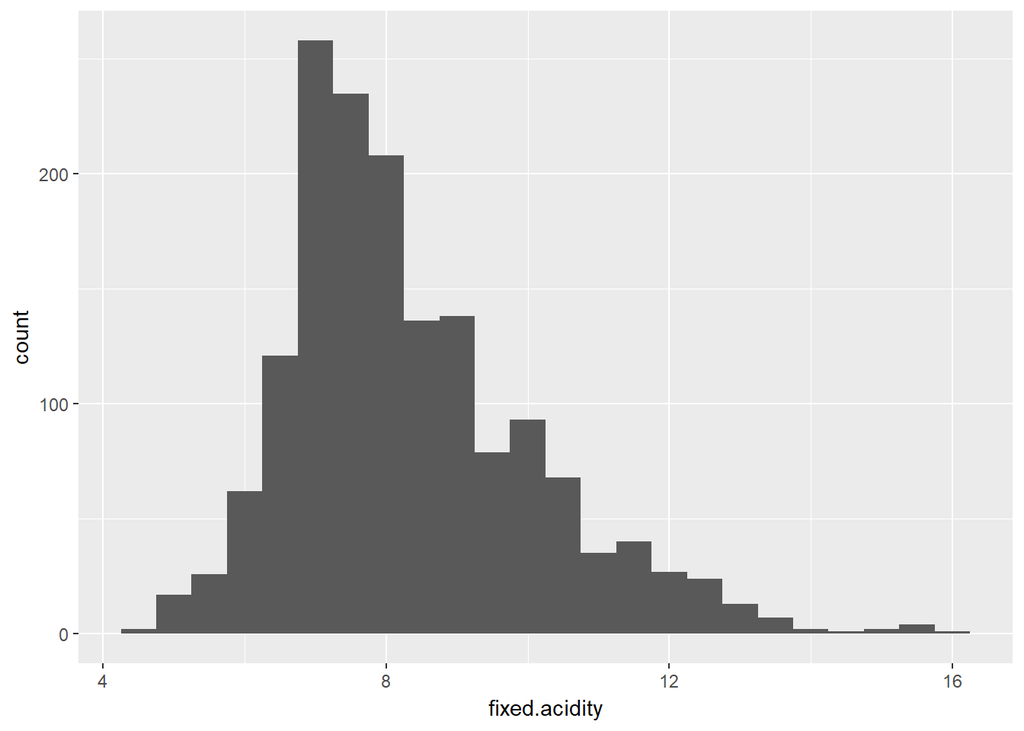

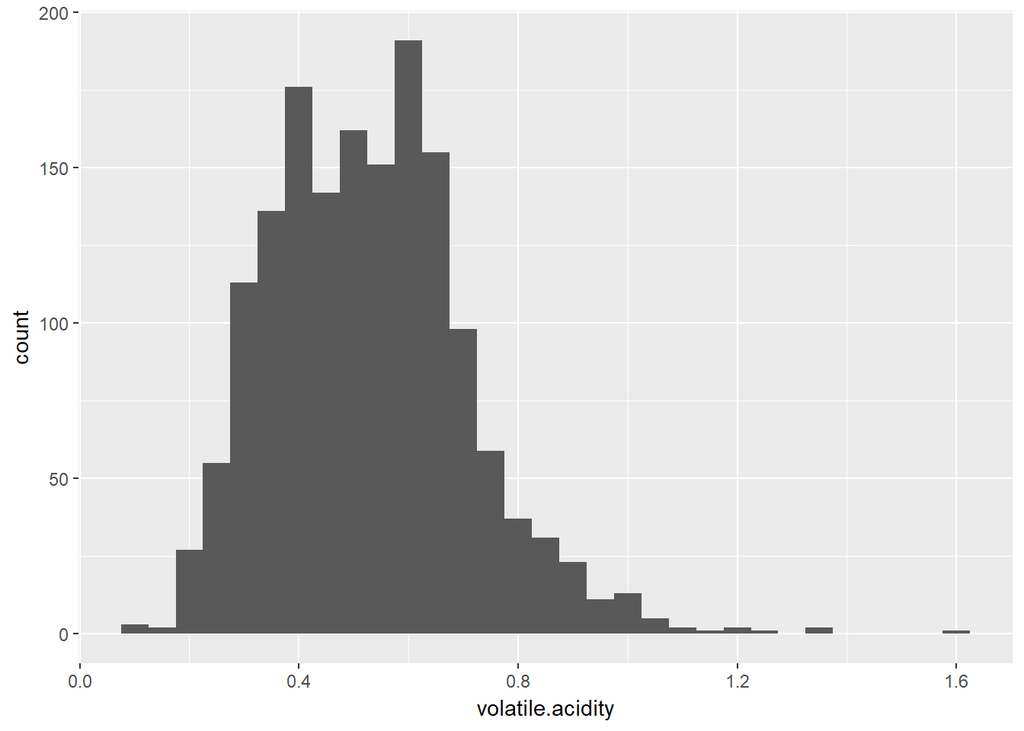

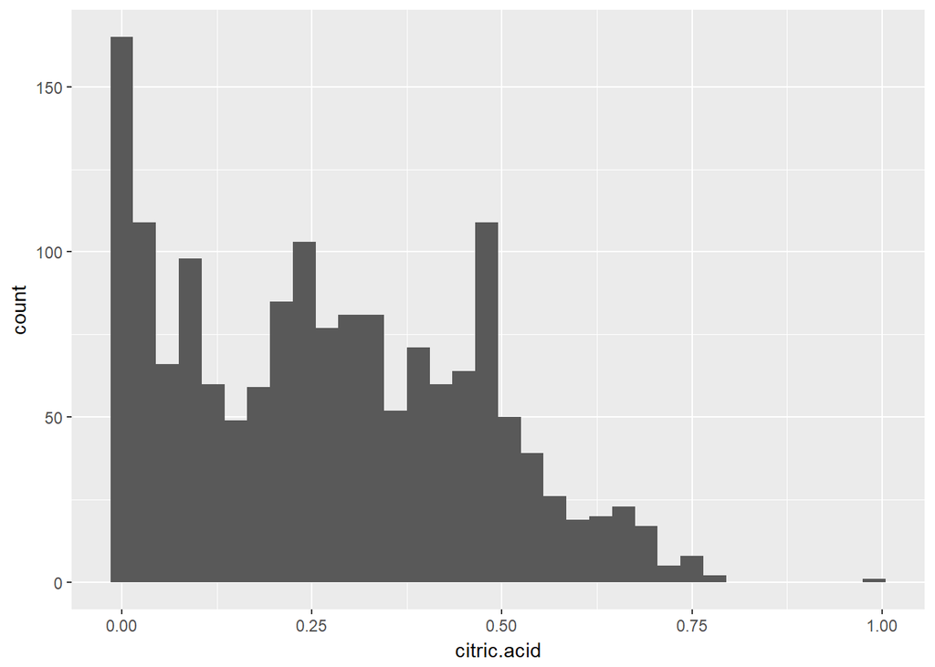

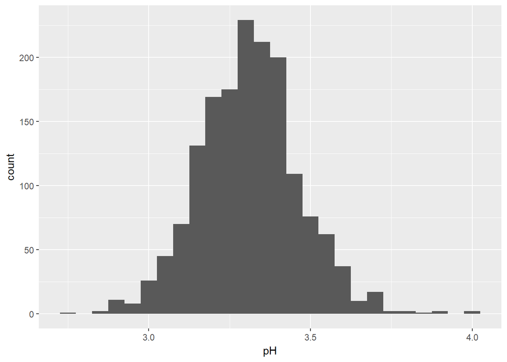

The pH of red wines is normally distributed while the three acidities of interest, fixed, volatile, and citric, are right-skewed. This makes particular sense for volatile acidity, which is known to introduce a bitter unpleasant taste in wines when found in higher concentrations. Additionally, citric acid’s curve looks irregular, multi-modal.

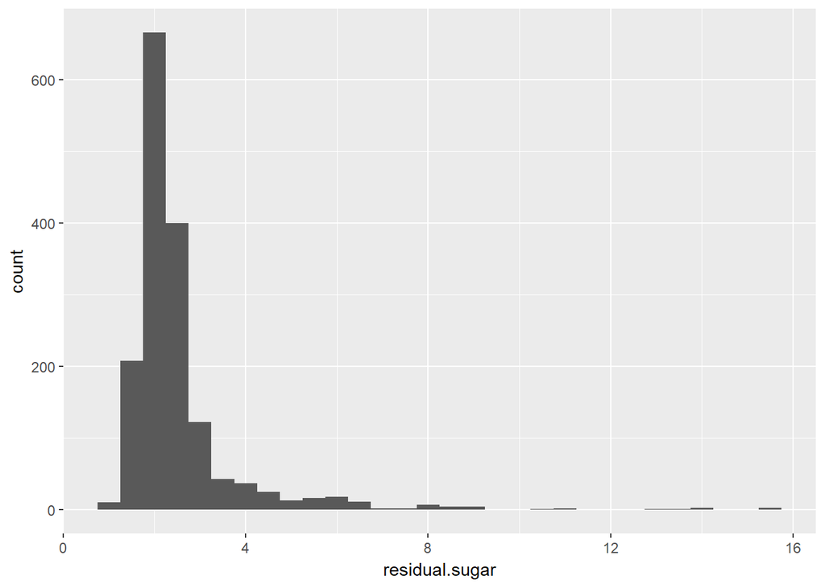

```
##    Min. 1st Qu.  Median    Mean 3rd Qu.    Max.
##   0.900   1.900   2.200   2.539   2.600  15.500
```